# Exercise 6.4

Manuela Giansante

2022-11-09

```r
library(data.table) #for reading the dataset
library(naniar) # missing values
library(caret) # for processing the data
library(kableExtra) # to make html tables
library(forecast) # for the predict and accuracy functions
library(leaps) # for selection of the variables
library(GGally) # for the correlation plot
```

```r
df <- fread("ToyotaCorolla.csv") #import the dataset
df2<- as.data.frame(df[,c("Price", "Age_08_04", "KM","Fuel_Type", "HP", "Automatic", "Doors", "Quarterly_Tax", "Mfr_Guarantee", "Guarantee_Period", "Airco", "Automatic_airco", "CD_Player", "Powered_Windows", "Sport_Model", "Tow_Bar")]) # filtered the dataset to the variables recommended by the book
str(df2) #structure of the dataset
```

```
## 'data.frame':    1436 obs. of  16 variables:
##  $ Price           : int  13500 13750 13950 14950 13750 12950 16900 18600 21500 12950 ...
##  $ Age_08_04       : int  23 23 24 26 30 32 27 30 27 23 ...
##  $ KM              : int  46986 72937 41711 48000 38500 61000 94612 75889 19700 71138 ...
##  $ Fuel_Type       : chr  "Diesel" "Diesel" "Diesel" "Diesel" ...
##  $ HP              : int  90 90 90 90 90 90 90 90 192 69 ...
##  $ Automatic       : int  0 0 0 0 0 0 0 0 0 0 ...
##  $ Doors           : int  3 3 3 3 3 3 3 3 3 3 ...
##  $ Quarterly_Tax   : int  210 210 210 210 210 210 210 210 100 185 ...
##  $ Mfr_Guarantee   : int  0 0 1 1 1 0 0 1 0 0 ...
##  $ Guarantee_Period: int  3 3 3 3 3 3 3 3 3 3 ...
##  $ Airco           : int  0 1 0 0 1 1 1 1 1 1 ...
##  $ Automatic_airco : int  0 0 0 0 0 0 0 0 0 0 ...
##  $ CD_Player       : int  0 1 0 0 0 0 0 1 0 0 ...
##  $ Powered_Windows : int  1 0 0 0 1 1 1 1 1 0 ...
##  $ Sport_Model     : int  0 0 0 0 0 0 1 0 0 0 ...
##  $ Tow_Bar         : int  0 0 0 0 0 0 0 0 0 0 ...
```

```r
summary(df2) # main stats from the dataset
```

```
##      Price         Age_08_04           KM          Fuel_Type
##  Min.   : 4350   Min.   : 1.00   Min.   :     1   Length:1436
##  1st Qu.: 8450   1st Qu.:44.00   1st Qu.: 43000   Class :character
##  Median : 9900   Median :61.00   Median : 63390   Mode  :character
##  Mean   :10731   Mean   :55.95   Mean   : 68533
##  3rd Qu.:11950   3rd Qu.:70.00   3rd Qu.: 87021
##  Max.   :32500   Max.   :80.00   Max.   :243000
##        HP          Automatic           Doors       Quarterly_Tax
##  Min.   : 69.0   Min.   :0.00000   Min.   :2.000   Min.   : 19.00
##  1st Qu.: 90.0   1st Qu.:0.00000   1st Qu.:3.000   1st Qu.: 69.00
##  Median :110.0   Median :0.00000   Median :4.000   Median : 85.00
##  Mean   :101.5   Mean   :0.05571   Mean   :4.033   Mean   : 87.12
##  3rd Qu.:110.0   3rd Qu.:0.00000   3rd Qu.:5.000   3rd Qu.: 85.00
##  Max.   :192.0   Max.   :1.00000   Max.   :5.000   Max.   :283.00
##  Mfr_Guarantee    Guarantee_Period     Airco        Automatic_airco
##  Min.   :0.0000   Min.   : 3.000   Min.   :0.0000   Min.   :0.00000
##  1st Qu.:0.0000   1st Qu.: 3.000   1st Qu.:0.0000   1st Qu.:0.00000
##  Median :0.0000   Median : 3.000   Median :1.0000   Median :0.00000
##  Mean   :0.4095   Mean   : 3.815   Mean   :0.5084   Mean   :0.05641
##  3rd Qu.:1.0000   3rd Qu.: 3.000   3rd Qu.:1.0000   3rd Qu.:0.00000
##  Max.   :1.0000   Max.   :36.000   Max.   :1.0000   Max.   :1.00000
##    CD_Player      Powered_Windows  Sport_Model        Tow_Bar
##  Min.   :0.0000   Min.   :0.000   Min.   :0.0000   Min.   :0.0000
##  1st Qu.:0.0000   1st Qu.:0.000   1st Qu.:0.0000   1st Qu.:0.0000
##  Median :0.0000   Median :1.000   Median :0.0000   Median :0.0000
##  Mean   :0.2187   Mean   :0.562   Mean   :0.3001   Mean   :0.2779
##  3rd Qu.:0.0000   3rd Qu.:1.000   3rd Qu.:1.0000   3rd Qu.:1.0000
##  Max.   :1.0000   Max.   :1.000   Max.   :1.0000   Max.   :1.0000
```

```r
sapply(df2, function(x) length(unique(x))) # length of the variabls
```

```
##            Price        Age_08_04               KM        Fuel_Type
##              236               77             1263                3
##               HP        Automatic            Doors    Quarterly_Tax
##               12                2                4               13
##    Mfr_Guarantee Guarantee_Period            Airco  Automatic_airco
##                2                9                2                2
##        CD_Player  Powered_Windows      Sport_Model          Tow_Bar
##                2                2                2                2
```

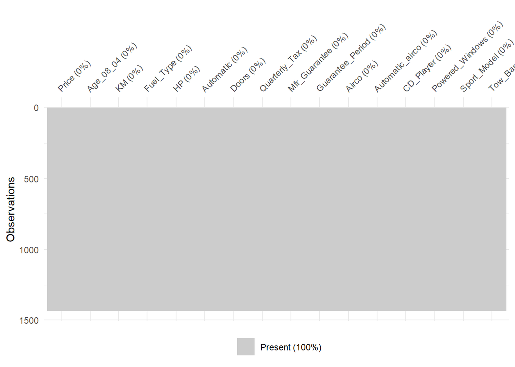

```r
vis_miss(df2, warn_large_data =  FALSE) # missing data analysis
```

There are no missing values. When we call for the summary of the dataset, we notice that the variable Fuel_Type is of class character, and it takes the values Diesel, Petrol, CNG. The variable HP refers to horse-power (table 6.1) We enumerate the dummies in the dataset: Automatic, Mfr_Guarantee, Airco, Automatic_airco, CD_Player, Powered_Windows, Sport_Model, Tow_Bar. Whilst for the mileage of these cars, the record is measure in Kilometers and it has a minimum value of 1 km and a maximum value of 243,000 km.

```r
df2$Fuel_TypeP <- ifelse(df2$Fuel_Type == "Petrol", 1, 0) # we add a dummy for the kinds of  each car uses
df2$Fuel_TypeD <- ifelse(df2$Fuel_Type == "Diesel", 1, 0)
df2$Fuel_TypeC <- ifelse(df2$Fuel_Type == "CNG", 1, 0)
df2<-as.data.frame(df2[,-c(4,19)])# we drop the old fuel type variable and the dummy for CNG to avoid multicollinearity
sapply(df2, function(x) length(unique(x)))# unique length of the variables
```

```
##            Price        Age_08_04               KM               HP
##              236               77             1263               12
##        Automatic            Doors    Quarterly_Tax    Mfr_Guarantee
##                2                4               13                2
## Guarantee_Period            Airco  Automatic_airco        CD_Player
##                9                2                2                2
##  Powered_Windows      Sport_Model          Tow_Bar       Fuel_TypeP
##                2                2                2                2
##       Fuel_TypeD
##                2
```

we have added a dummy variable to model numerically the Fuel_Type variable, the variable related to CNG is dropped to avoid multi-collinearity in the linear regression.The function lm would do that for us actually, so this is a bit of a superfluous step.

[figure not shown]

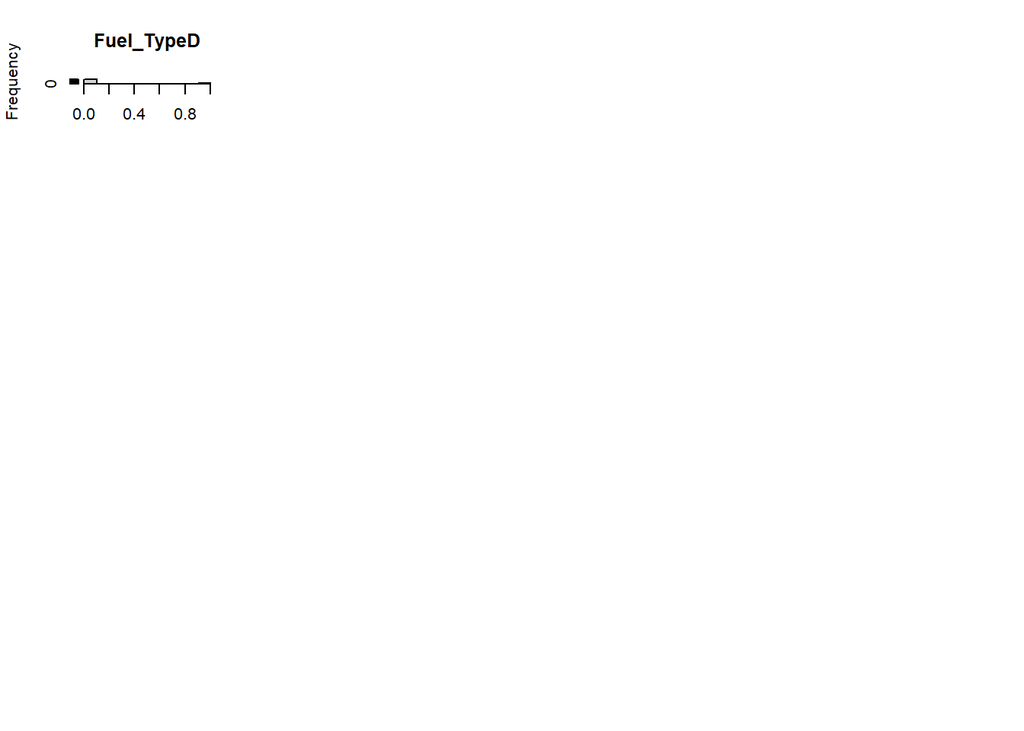

```r
par(mfrow = c(4, 4))  # create grid for plots
#for loop to pot histograms for all variables
for (col in c(1:ncol(df2))) {
  hist(df2[,col], main = names(df2[col]), xlab = "")
  #boxplot(cereals_num[,col], main = names(cereals_num[col]), xlab = "")
}
```

These features they describe the used cars, many are non-numerical. Age is skewed to the left and quite spread out, which makes sense given we are dealing with a data-set, describing used cars. Price clusters to the left but all in all the distribution seems normal KM and Hp are not symmetrical. Quarterly Tax as confirmed by the unique length function takes few variables, a majority share of them seems to fall in the interval 50-100.

The rest are non. numerical variables, as in they take a 0,1 value, Airco and Mfr_Guarantee seem to be more evenly assigned, than others.

```r
set.seed(1)  # controlled random numbers, to have the same samples when we re-run the code
training<- sample(row.names(df2), 0.5*dim(df2)[1]) #  training set 50% of the data
validation  <- sample(setdiff(row.names(df2), training ),  0.3*dim(df2)[1]) # validation set 30%
test <- setdiff(rownames(df2), union(training, validation))
train.df<- df2[training,] # training set as individual data.frame
valid.df<- df2[validation,] # validation set as individual data.frame
test.df <- df2[test,]
```

The dataset is now been partitioned in a 50% training set, 30% validation and 20% test set.

```r
options(Scipen = 999)
car.lm <- lm(Price ~ .,data=train.df)# we run a multivariate linear regression
summary(car.lm) #recall the results
```

```
##
## Call:
## lm(formula = Price ~ ., data = train.df)
##
## Residuals:
##     Min      1Q  Median      3Q     Max
## -5180.3  -751.4   -54.5   662.3  7110.1
##
## Coefficients:
##                    Estimate Std. Error t value Pr(>|t|)
## (Intercept)       9.686e+03  7.806e+02  12.409  < 2e-16 ***
## Age_08_04        -1.081e+02  4.102e+00 -26.346  < 2e-16 ***
## KM               -1.876e-02  1.873e-03 -10.013  < 2e-16 ***
## HP                3.871e+01  4.417e+00   8.764  < 2e-16 ***
## Automatic         4.574e+02  2.301e+02   1.988 0.047201 *
## Doors             1.923e+02  5.252e+01   3.662 0.000269 ***
## Quarterly_Tax     1.324e+01  2.440e+00   5.426 7.96e-08 ***
## Mfr_Guarantee     2.482e+02  1.014e+02   2.447 0.014642 *
## Guarantee_Period  7.452e+01  1.822e+01   4.089 4.83e-05 ***
## Airco             1.915e+02  1.215e+02   1.577 0.115349
## Automatic_airco   3.181e+03  2.368e+02  13.434  < 2e-16 ***
## CD_Player         4.741e+02  1.322e+02   3.586 0.000359 ***
## Powered_Windows   3.957e+02  1.180e+02   3.355 0.000838 ***
## Sport_Model       5.272e+02  1.096e+02   4.809 1.85e-06 ***
## Tow_Bar          -2.447e+02  1.130e+02  -2.166 0.030657 *
## Fuel_TypeP        1.345e+03  5.493e+02   2.448 0.014606 *
## Fuel_TypeD        2.170e+03  5.265e+02   4.122 4.21e-05 ***
## ---
## Signif. codes:  0 '***' 0.001 '**' 0.01 '*' 0.05 '.' 0.1 ' ' 1
##
## Residual standard error: 1260 on 701 degrees of freedom
## Multiple R-squared:  0.8874, Adjusted R-squared:  0.8848
## F-statistic: 345.2 on 16 and 701 DF,  p-value: < 2.2e-16
```

We have run a linear regression with the Price as the outcome variable and all the others as predictors. All our variables are measured by different units. We try to standardize them and see if the coefficients change in importance.

```r
train.stand.df <- train.df # initializing variables, for training set
valid.stand.df <-valid.df  # for validation set
test.stand.df <- test.df   # for test set

stand.values <- preProcess(train.df[, c(1,2,3,4,6,7,9)], method=c("center", "scale")) # pre-processing training set
# method center subtract the mean of the numerical predictors data from the predictors value
# method scale divides by the standard deviation
train.stand.df[, c(1,2,3,4,6,7,9)]<- predict(stand.values, train.df[, c(1,2,3,4,6,7,9)]) #training set, numerical variables
valid.stand.df[, c(1,2,3,4,6,7,9)]<-  predict(stand.values, valid.df[, c(1,2,3,4,6,7,9)]) #validation set, numerical values
test.stand.df[,c(1,2,3,4,6,7,9)] <- predict(stand.values, test.df[,c(1,2,3,4,6,7,9)]) #test set, numerical values
```

```r
options(scipen = 999) # scientific notation, recommended by the book (table 6.3)
car.lm.stand <- lm(Price ~ .,data=train.stand.df) # we re-run the regression
summary(car.lm.stand) # recall the results
```

```
##
## Call:
## lm(formula = Price ~ ., data = train.stand.df)
##
## Residuals:
##      Min       1Q   Median       3Q      Max
## -1.39545 -0.20242 -0.01468  0.17840  1.91530
##
## Coefficients:
##                  Estimate Std. Error t value             Pr(>|t|)
## (Intercept)      -0.60794    0.14321  -4.245         0.0000247949 ***
## Age_08_04        -0.54127    0.02054 -26.346 < 0.0000000000000002 ***
## KM               -0.18515    0.01849 -10.013 < 0.0000000000000002 ***
## HP                0.15210    0.01735   8.764 < 0.0000000000000002 ***
## Automatic         0.12320    0.06197   1.988             0.047201 *
## Doors             0.04943    0.01350   3.662             0.000269 ***
## Quarterly_Tax     0.14677    0.02705   5.426         0.0000000796 ***
## Mfr_Guarantee     0.06685    0.02732   2.447             0.014642 *
## Guarantee_Period  0.05534    0.01353   4.089         0.0000483113 ***
## Airco             0.05159    0.03272   1.577             0.115349
## Automatic_airco   0.85687    0.06378  13.434 < 0.0000000000000002 ***
## CD_Player         0.12772    0.03561   3.586             0.000359 ***
## Powered_Windows   0.10659    0.03177   3.355             0.000838 ***
## Sport_Model       0.14201    0.02953   4.809         0.0000018536 ***
## Tow_Bar          -0.06591    0.03043  -2.166             0.030657 *
## Fuel_TypeP        0.36226    0.14798   2.448             0.014606 *
## Fuel_TypeD        0.58458    0.14183   4.122         0.0000421240 ***
## ---
## Signif. codes:  0 '***' 0.001 '**' 0.01 '*' 0.05 '.' 0.1 ' ' 1
##
## Residual standard error: 0.3394 on 701 degrees of freedom
## Multiple R-squared:  0.8874, Adjusted R-squared:  0.8848
## F-statistic: 345.2 on 16 and 701 DF,  p-value: < 0.00000000000000022
```

We notice that the mileage coefficient has gained in relevance after having formatted the data to something with mean zero and SD=1 to make comparison easier. Moreover, we notice the 88% of explained variation described by the adjusted R^2.The regular R^2 is very similar to the adjusted one, just slightly higher. The percentage it is quite high so the model does a decent job at explaining variation in the records. The model also has a very small P-value.

### Most importat predictors:

### 6.4.a

The most important variable for price prediction seem to be age, mileage, horsepower and automatic airco. That is because their are statistically significant and the absolute values of their coefficients are larger than other variables’ coefficients. It followsw that their p-values are also ver small. The two dummies for Petrol and Diesel have large coefficient, respectively `0.362` and `0.584` , but the Petrol one is not as significant.

- The Age variable with a coefficient of `-0.541`
- The Mileage coefficient amounts to `-0.185`
- The Automatic air-conditioning predictor has the highest impact on price with a coefficient of `0.857`

The negative coefficient for the age predictor seems coherent with the idea, that the older the lower the price of it. Same reasoning holds for the negative relationship mileage has with price. The air conditioning brings the price up by the “largest” factor, given the data is standardized and therefore comparable.

The variable Airco, doesn’t show up as significant, maybe for redundancy with the Automatic_airco, This could be a good candidate for dropping of variables.

```r
df2.lm.pred<- predict(car.lm, valid.df) # we are using non standardized values, because the price is a continuous variable and we want interpretable results
options(Scipen=999, digits=3) #positive values towards fixed and negative towards scientific notation, 3 significant values

some_residuals<- valid.stand.df[c(1:20),1] - df2.lm.pred[1:20] # we compute some residuals
res<- data.frame("Predicted"=df2.lm.pred[1:20], "Actual"= valid.df$Price[1:20], "Residuals"= some_residuals)# we build a data.frame for it
head(res)
```

```
##     Predicted Actual Residuals
## 274     13457  13450    -13456
## 965      9842  10950     -9842
## 477     11155  10250    -11156
## 558     10455  13750    -10454
## 942     10202   9250    -10202
## 47      16805  17950    -16804
```

Then to counter check whether this procedure yielded the right results we computed the re-scaled the Price variable and its predictions (generated by the `car.lm.stand` regression).

```r
stand.values$mean[1] #mean of price
```

```
## Price
## 10904
```

```r
stand.values$std[1] # std of the price used in the standardisation process
```

```
## Price
##  3712
```

```r
#table 6.4, we make a data frame out of the actual records in the valid.stand.df, the predictions
rescaled_price<- data.table("Records" = valid.stand.df$Price, "Predictions" = predict(car.lm.stand, valid.stand.df))
rescaled_price <- rescaled_price[, Records := Records*stand.values$std[1] + stand.values$mean[1] ] #re-scale the Records
rescaled_price <- rescaled_price[, Predictions := Predictions*stand.values$std[1] + stand.values$mean[1] ] #re-scale the Predictions
rescaled_price <- rescaled_price[, Residuals := Records - Predictions] #compute the residuals and add a column
head(rescaled_price)
```

```
##    Records Predictions Residuals
## 1:   13450       13457     -6.67
## 2:   10950        9842   1108.08
## 3:   10250       11155   -905.41
## 4:   13750       10455   3295.33
## 5:    9250       10202   -951.53
## 6:   17950       16805   1144.52
```

```r
kable(res, row.names = T) %>% kable_paper("hover", full_width = T)  #presentation of our residuals table
```

|  | Predicted | Actual | Residuals |
| --- | --- | --- | --- |
| 274 | 13457 | 13450 | -13456 |
| 965 | 9842 | 10950 | -9842 |
| 477 | 11155 | 10250 | -11156 |
| 558 | 10455 | 13750 | -10454 |
| 942 | 10202 | 9250 | -10202 |
| 47 | 16805 | 17950 | -16804 |
| 1061 | 5989 | 7950 | -5990 |
| 639 | 9013 | 10450 | -9013 |
| 1223 | 8339 | 8250 | -8340 |
| 272 | 12838 | 12950 | -12837 |
| 1417 | 7661 | 8950 | -7662 |
| 1294 | 8328 | 8500 | -8328 |
| 1241 | 6524 | 8750 | -6525 |
| 809 | 8986 | 8250 | -8987 |
| 1039 | 10087 | 9245 | -10088 |
| 627 | 10431 | 8950 | -10432 |
| 1282 | 8347 | 7400 | -8348 |
| 699 | 9405 | 10250 | -9405 |
| 224 | 12509 | 14950 | -12508 |
| 1170 | 8334 | 9250 | -8334 |

```r
all.residuals<- valid.df[,1] - df2.lm.pred # we compute all residuals
mean(all.residuals)
```

```
## [1] 34
```

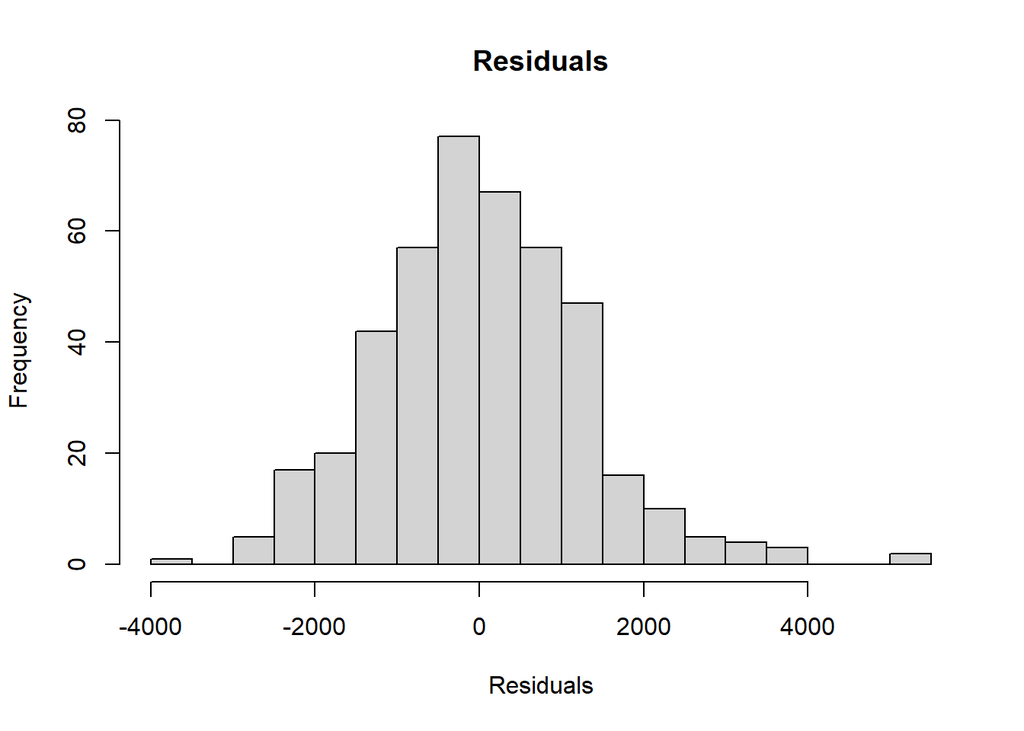

```r
hist(all.residuals, breaks=25, xlab="Residuals", main="Residuals") #we plot them to see if they are normally distributed
```

Our residuals seem normally distributed enough , and most of the residuals are within an interval of 2000 dollars. This normal distribution of residuals, in which the histogram is not obviously skewed tells us that there are prices that by the model get over estimated and under estimated. AS expected the linear regression will miss those very high and very low values.

We proceed at analyzing the accuracy measures.

```r
options(scipen=999, digits=3) #positive values towards fixed and negative towards scientific notation, 3 significant values
acc<- data.frame(accuracy(df2.lm.pred, valid.df$Price)) # compute accuracy measures
summary(valid.df$Price) # main stats for price values
```

```
##    Min. 1st Qu.  Median    Mean 3rd Qu.    Max.
##    4450    8450    9500   10589   11950   23950
```

```r
sd(valid.df$Price) # standard deviation
```

```
## [1] 3450
```

```r
kable(acc, row.names = T)%>% kable_paper("hover", full_width = T) #presentation
```

|  | ME | RMSE | MAE | MPE | MAPE |
| --- | --- | --- | --- | --- | --- |
| Test set | 34 | 1256 | 969 | -0.519 | 9.64 |

In this case we evaluate over the validation set, because we want to see the performance of our model.

The ME tells us the mean of our residuals, and it amounts to $34. The Mean Absolute Error is $969, that is what on average the error on the predictions of price amounts to, this error also varies by 9.64% on average. The Root Mean Squared Error of the regression is $1256, which the average size of the errors. Both these measures take small value compared to the mean value $10,589, yet it depends on what this evaluation is used for.

### variable selection:

```r
corr_price <- round(cor(train.df),2) #approximate the correlation between Price and all the other predictors
# on non standardized values, because its definition is not connected to range
kable(corr_price[,1]) %>% kable_paper("hover", "striped", full_width=T) %>%
  column_spec(1, bold = T, border_right = T) #make a table out of it
```

|  | x |
| --- | --- |
| Price | 1.00 |
| Age_08_04 | -0.87 |
| KM | -0.57 |
| HP | 0.31 |
| Automatic | 0.05 |
| Doors | 0.18 |
| Quarterly_Tax | 0.27 |
| Mfr_Guarantee | 0.22 |
| Guarantee_Period | 0.08 |
| Airco | 0.42 |
| Automatic_airco | 0.58 |
| CD_Player | 0.49 |
| Powered_Windows | 0.35 |
| Sport_Model | 0.20 |
| Tow_Bar | -0.20 |
| Fuel_TypeP | -0.09 |
| Fuel_TypeD | 0.11 |

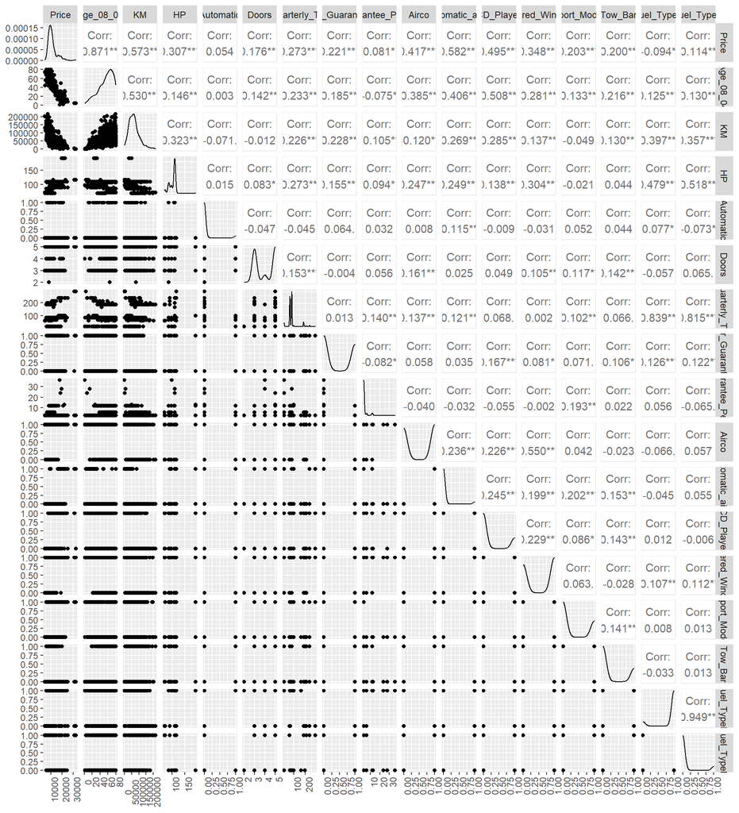

```r
ggpairs(train.df)+ # select the quantitative variables
  theme(strip.text.x= element_text(size= 9), # make strip text readable
        strip.text.y = element_text(size= 9),
    axis.text.x.bottom = element_text(angle = 90, size = 9), #turn x axis text by 90 degrees to increase readability
        axis.text.y.left = element_text(size= 9))
```

### Exhaustive search:

```r
search<- regsubsets(Price ~ ., data=train.stand.df, nbest = 1, nvmax= dim(train.stand.df)[2], method = "exhaustive")
sum<- summary(search)
sum$which # summary of exhaustive search
```

```
##    (Intercept) Age_08_04    KM    HP Automatic Doors Quarterly_Tax
## 1         TRUE      TRUE FALSE FALSE     FALSE FALSE         FALSE
## 2         TRUE      TRUE FALSE FALSE     FALSE FALSE         FALSE
## 3         TRUE      TRUE FALSE  TRUE     FALSE FALSE         FALSE
## 4         TRUE      TRUE FALSE  TRUE     FALSE FALSE          TRUE
## 5         TRUE      TRUE  TRUE  TRUE     FALSE FALSE          TRUE
## 6         TRUE      TRUE  TRUE  TRUE     FALSE FALSE          TRUE
## 7         TRUE      TRUE  TRUE  TRUE     FALSE FALSE          TRUE
## 8         TRUE      TRUE  TRUE  TRUE     FALSE FALSE          TRUE
## 9         TRUE      TRUE  TRUE  TRUE     FALSE FALSE          TRUE
## 10        TRUE      TRUE  TRUE  TRUE     FALSE  TRUE          TRUE
## 11        TRUE      TRUE  TRUE  TRUE     FALSE  TRUE          TRUE
## 12        TRUE      TRUE  TRUE  TRUE     FALSE  TRUE          TRUE
## 13        TRUE      TRUE  TRUE  TRUE     FALSE  TRUE          TRUE
## 14        TRUE      TRUE  TRUE  TRUE     FALSE  TRUE          TRUE
```

[output cut: 36 more lines]

```r
sum$rsq # regular R^2
```

```
##  [1] 0.758 0.821 0.838 0.851 0.869 0.873 0.875 0.877 0.880 0.882 0.883 0.885
## [13] 0.886 0.886 0.887 0.887
```

```r
sum$adjr2 # adjusted R^2
```

```
##  [1] 0.758 0.820 0.837 0.850 0.868 0.872 0.874 0.876 0.878 0.880 0.882 0.883
## [13] 0.884 0.884 0.885 0.885
```

```r
sum$cp #Mallow's Cp
```

```
##  [1] 793.0 404.8 298.8 218.1 111.8  89.1  75.0  62.6  51.0  40.9  32.3  25.8
## [13]  21.7  19.8  17.5  17.0
```

We run an exhaustive search, meaning we evaluate possible predictors subsets, in this case we are looking over a set of 16 predictors, ergo we evaluate 16 models. If we observe regular R^2, so the percentage of variation explained by the predictors increases steadily as we include more and more variables. Adjusted R^2 adds a penalty for every new variable, therefore accounting for the bias-variance trade off we are currently leading. In this case R^2 adj seems to be behaving basically the same way regular R^2 does, meaning that all these variables seem to increase the portion of variation described by the model.

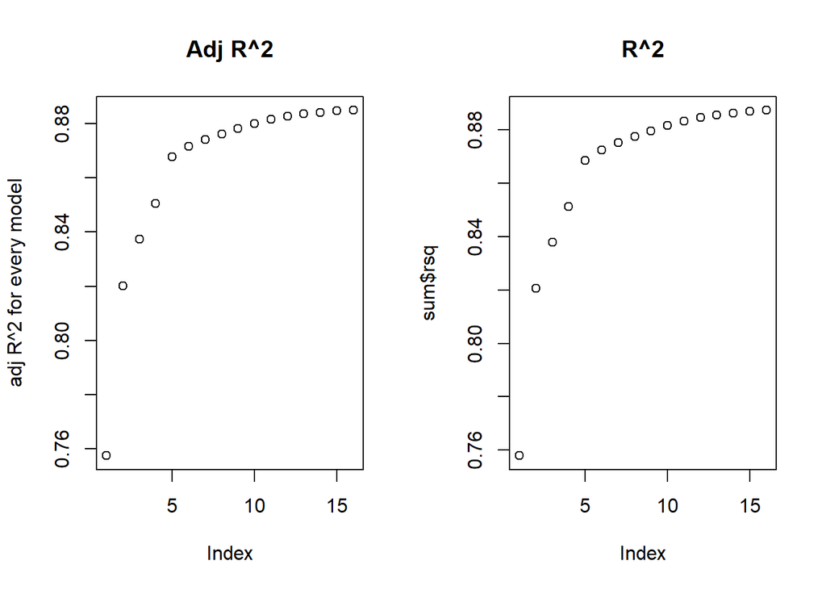

```r
par(mfrow = c(1,2)) #we plot the evolution of the R^2 two values
plot(sum$adjr2, ylab="adj R^2 for every model", main="Adj R^2") #adjusted R^2
plot(sum$rsq, ylba="R^2 for every model", main = "R^2") #regular R^2
```

The adjusted R^2 is slightly flatter on top, meaning there decreasing gains in explained variation as we add variables, which is to be expected.

```r
sum$cp #Mallow's Cp
```

```
##  [1] 793.0 404.8 298.8 218.1 111.8  89.1  75.0  62.6  51.0  40.9  32.3  25.8
## [13]  21.7  19.8  17.5  17.0
```

The Mallow’s method for subset selection assumes that the full model is unbiased, meaning that by including all the predictors would produce a model with no bias. The model with the lowest Cp value is the one that includes all predictors, in fact 17.0 which equals our 16 predictors plus 1.

### Backward elimination:

```r
x<- formula(lm(Price ~.,train.df))
car.lm.bac <- step (car.lm, direction='backward', scope=x) #backwards elimination,scope defines the set of models searched
```

```
## Start:  AIC=10268
## Price ~ Age_08_04 + KM + HP + Automatic + Doors + Quarterly_Tax +
##     Mfr_Guarantee + Guarantee_Period + Airco + Automatic_airco +
##     CD_Player + Powered_Windows + Sport_Model + Tow_Bar + Fuel_TypeP +
##     Fuel_TypeD
##
##                    Df  Sum of Sq        RSS   AIC
## <none>                           1112745704 10268
## - Airco             1    3945445 1116691149 10269
## - Automatic         1    6273467 1119019171 10270
## - Tow_Bar           1    7446395 1120192099 10271
## - Mfr_Guarantee     1    9506259 1122251963 10272
## - Fuel_TypeP        1    9513213 1122258916 10272
## - Powered_Windows   1   17863011 1130608715 10278
## - CD_Player         1   20414506 1133160210 10279
## - Doors             1   21285929 1134031632 10280
## - Guarantee_Period  1   26542914 1139288618 10283
## - Fuel_TypeD        1   26965773 1139711477 10283
## - Sport_Model       1   36716995 1149462699 10289
## - Quarterly_Tax     1   46726921 1159472625 10296
## - HP                1  121935323 1234681027 10341
## - KM                1  159136731 1271882435 10362
## - Automatic_airco   1  286480093 1399225797 10431
## - Age_08_04         1 1101813022 2214558726 10760
```

```r
 # this way is equivalent of leaving the argument scope unspecified
car.lm.bac.pred <- predict(car.lm.bac, valid.df) # how it performs on validation/test set
accuracy_mb<- accuracy(car.lm.bac.pred, valid.df$Price) # accuracy measures on the selected model
kable(accuracy_mb, row.names = T)%>% kable_paper("hover", full_width = T) #presentation
```

|  | ME | RMSE | MAE | MPE | MAPE |
| --- | --- | --- | --- | --- | --- |
| Test set | 34 | 1256 | 969 | -0.519 | 9.64 |

In backward elimination we start from a complete model and then at each “iteration” we eliminate the least useful variable.

### Forward selection:

```r
car.lm.null<- lm(Price~1, data= train.stand.df) # we compute a lm without any variable as a starting point for our forward selection
car.lm.for <- step(car.lm.null,scope=list(lower=car.lm.null, upper=car.lm.stand), direction='forward') #the scope of the search is between the empty model and the complete one
```

```
## Start:  AIC=1
## Price ~ 1
##
##                    Df Sum of Sq RSS   AIC
## + Age_08_04         1       543 174 -1015
## + Automatic_airco   1       243 474  -294
## + KM                1       235 482  -283
## + CD_Player         1       176 541  -199
## + Airco             1       125 592  -134
## + Powered_Windows   1        87 630   -90
## + HP                1        67 650   -68
## + Quarterly_Tax     1        54 663   -53
## + Mfr_Guarantee     1        35 682   -33
## + Sport_Model       1        30 687   -27
## + Tow_Bar           1        29 688   -26
## + Doors             1        22 695   -19
## + Fuel_TypeD        1         9 708    -6
## + Fuel_TypeP        1         6 711    -3
## + Guarantee_Period  1         5 712    -2
## + Automatic         1         2 715     1
## <none>                          717     1
##
## Step:  AIC=-1015
## Price ~ Age_08_04
##
##                    Df Sum of Sq RSS   AIC
## + Automatic_airco   1      44.9 129 -1229
## + HP                1      23.6 150 -1118
## + KM                1      12.5 161 -1067
## + Powered_Windows   1       8.3 165 -1049
## + Airco             1       5.6 168 -1037
## + Sport_Model       1       5.6 168 -1037
## + Quarterly_Tax     1       3.7 170 -1029
## + CD_Player         1       2.6 171 -1024
## + Mfr_Guarantee     1       2.6 171 -1024
## + Automatic         1       2.3 171 -1023
## + Doors             1       2.0 172 -1022
## <none>                          174 -1015
## + Guarantee_Period  1       0.2 173 -1014
## + Fuel_TypeP        1       0.2 173 -1014
```

[output cut: 199 more lines]

```
## Step:  AIC=-1534
## Price ~ Age_08_04 + Automatic_airco + HP + Quarterly_Tax + KM +
##     Powered_Windows + Sport_Model + Guarantee_Period + CD_Player +
##     Doors + Fuel_TypeD + Mfr_Guarantee + Fuel_TypeP + Tow_Bar +
##     Automatic
##
##         Df Sum of Sq  RSS   AIC
## + Airco  1     0.286 80.7 -1535
## <none>               81.0 -1534
##
## Step:  AIC=-1535
## Price ~ Age_08_04 + Automatic_airco + HP + Quarterly_Tax + KM +
##     Powered_Windows + Sport_Model + Guarantee_Period + CD_Player +
##     Doors + Fuel_TypeD + Mfr_Guarantee + Fuel_TypeP + Tow_Bar +
##     Automatic + Airco
```

```r
summary(car.lm.for) #print the computed models
```

```
##
## Call:
## lm(formula = Price ~ Age_08_04 + Automatic_airco + HP + Quarterly_Tax +
##     KM + Powered_Windows + Sport_Model + Guarantee_Period + CD_Player +
##     Doors + Fuel_TypeD + Mfr_Guarantee + Fuel_TypeP + Tow_Bar +
##     Automatic + Airco, data = train.stand.df)
##
## Residuals:
##     Min      1Q  Median      3Q     Max
## -1.3954 -0.2024 -0.0147  0.1784  1.9153
##
## Coefficients:
##                  Estimate Std. Error t value             Pr(>|t|)
## (Intercept)       -0.6079     0.1432   -4.25           0.00002479 ***
## Age_08_04         -0.5413     0.0205  -26.35 < 0.0000000000000002 ***
## Automatic_airco    0.8569     0.0638   13.43 < 0.0000000000000002 ***
## HP                 0.1521     0.0174    8.76 < 0.0000000000000002 ***
## Quarterly_Tax      0.1468     0.0271    5.43           0.00000008 ***
## KM                -0.1852     0.0185  -10.01 < 0.0000000000000002 ***
## Powered_Windows    0.1066     0.0318    3.35              0.00084 ***
## Sport_Model        0.1420     0.0295    4.81           0.00000185 ***
## Guarantee_Period   0.0553     0.0135    4.09           0.00004831 ***
## CD_Player          0.1277     0.0356    3.59              0.00036 ***
## Doors              0.0494     0.0135    3.66              0.00027 ***
## Fuel_TypeD         0.5846     0.1418    4.12           0.00004212 ***
## Mfr_Guarantee      0.0669     0.0273    2.45              0.01464 *
## Fuel_TypeP         0.3623     0.1480    2.45              0.01461 *
## Tow_Bar           -0.0659     0.0304   -2.17              0.03066 *
## Automatic          0.1232     0.0620    1.99              0.04720 *
## Airco              0.0516     0.0327    1.58              0.11535
## ---
## Signif. codes:  0 '***' 0.001 '**' 0.01 '*' 0.05 '.' 0.1 ' ' 1
##
## Residual standard error: 0.339 on 701 degrees of freedom
## Multiple R-squared:  0.887,  Adjusted R-squared:  0.885
## F-statistic:  345 on 16 and 701 DF,  p-value: <0.0000000000000002
```

In this case we have started from an empty model and then added a variable at the time, the smaller the AIC value the better. Equivalent to selecting the model through Mallow’s Cp value. The best performing one is the complete one.

### Step wise selection:

```r
car.lm.both <- step (car.lm.stand, direction="both")
```

```
## Start:  AIC=-1535
## Price ~ Age_08_04 + KM + HP + Automatic + Doors + Quarterly_Tax +
##     Mfr_Guarantee + Guarantee_Period + Airco + Automatic_airco +
##     CD_Player + Powered_Windows + Sport_Model + Tow_Bar + Fuel_TypeP +
##     Fuel_TypeD
##
##                    Df Sum of Sq   RSS   AIC
## <none>                           80.7 -1535
## - Airco             1       0.3  81.0 -1534
## - Automatic         1       0.5  81.2 -1533
## - Tow_Bar           1       0.5  81.3 -1532
## - Mfr_Guarantee     1       0.7  81.4 -1531
## - Fuel_TypeP        1       0.7  81.4 -1531
## - Powered_Windows   1       1.3  82.0 -1526
## - CD_Player         1       1.5  82.2 -1524
## - Doors             1       1.5  82.3 -1523
## - Guarantee_Period  1       1.9  82.7 -1520
## - Fuel_TypeD        1       2.0  82.7 -1520
## - Sport_Model       1       2.7  83.4 -1514
## - Quarterly_Tax     1       3.4  84.1 -1507
## - HP                1       8.8  89.6 -1462
## - KM                1      11.5  92.3 -1441
## - Automatic_airco   1      20.8 101.5 -1372
## - Age_08_04         1      80.0 160.7 -1043
```

```r
summary(car.lm.both)
```

```
##
## Call:
## lm(formula = Price ~ Age_08_04 + KM + HP + Automatic + Doors +
##     Quarterly_Tax + Mfr_Guarantee + Guarantee_Period + Airco +
##     Automatic_airco + CD_Player + Powered_Windows + Sport_Model +
##     Tow_Bar + Fuel_TypeP + Fuel_TypeD, data = train.stand.df)
##
## Residuals:
##     Min      1Q  Median      3Q     Max
## -1.3954 -0.2024 -0.0147  0.1784  1.9153
##
## Coefficients:
##                  Estimate Std. Error t value             Pr(>|t|)
## (Intercept)       -0.6079     0.1432   -4.25           0.00002479 ***
## Age_08_04         -0.5413     0.0205  -26.35 < 0.0000000000000002 ***
## KM                -0.1852     0.0185  -10.01 < 0.0000000000000002 ***
## HP                 0.1521     0.0174    8.76 < 0.0000000000000002 ***
## Automatic          0.1232     0.0620    1.99              0.04720 *
## Doors              0.0494     0.0135    3.66              0.00027 ***
## Quarterly_Tax      0.1468     0.0271    5.43           0.00000008 ***
## Mfr_Guarantee      0.0669     0.0273    2.45              0.01464 *
## Guarantee_Period   0.0553     0.0135    4.09           0.00004831 ***
## Airco              0.0516     0.0327    1.58              0.11535
## Automatic_airco    0.8569     0.0638   13.43 < 0.0000000000000002 ***
## CD_Player          0.1277     0.0356    3.59              0.00036 ***
## Powered_Windows    0.1066     0.0318    3.35              0.00084 ***
## Sport_Model        0.1420     0.0295    4.81           0.00000185 ***
## Tow_Bar           -0.0659     0.0304   -2.17              0.03066 *
## Fuel_TypeP         0.3623     0.1480    2.45              0.01461 *
## Fuel_TypeD         0.5846     0.1418    4.12           0.00004212 ***
## ---
## Signif. codes:  0 '***' 0.001 '**' 0.01 '*' 0.05 '.' 0.1 ' ' 1
##
## Residual standard error: 0.339 on 701 degrees of freedom
## Multiple R-squared:  0.887,  Adjusted R-squared:  0.885
## F-statistic:  345 on 16 and 701 DF,  p-value: <0.0000000000000002
```

```r
car.lm.both.pred <- predict(car.lm.both, valid.stand.df)
```

All, these methods yield the same answer, the complete model is the one that performs better. All, the observations we made regarding the accuracy of the complete model `car.lm.stand` are withstanding.